# Cluster Models

This notebook illustrates the following techniques: Cluster Analysis

Now, let us run cluster analysis. Install the following packages: “cluster, NbClust, flexclust, fMultivar, ggplot2, lattice, gridbase, gridextra”

Import the toy cluster dataset Import the Public Utilities Dataset

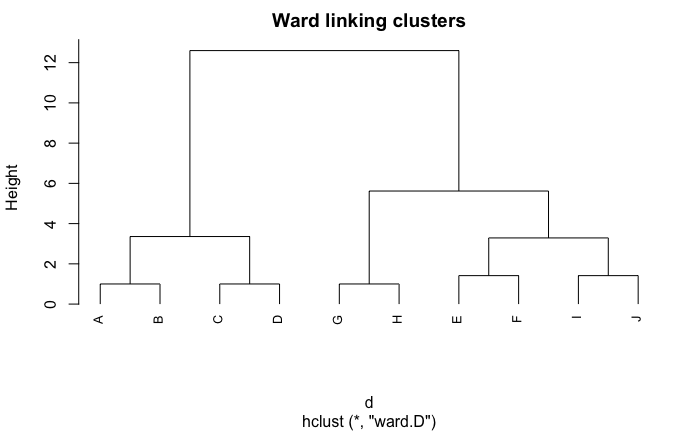

|  | Coverage | Return | Cost | Load | Peak | Sales | Nuclear | Fuel | Company |
| --- | --- | --- | --- | --- | --- | --- | --- | --- | --- |
| Arizona Public | 1.06 | 9.2 | 151 | 54.4 | 1.6 | 9077 | 0.0 | 0.628 | Arizona Public |
| Boston Edison | 0.89 | 10.3 | 202 | 57.9 | 2.2 | 5088 | 25.3 | 1.555 | Boston Edison |
| Central Louisiana | 1.43 | 15.4 | 113 | 53.0 | 3.4 | 9212 | 0.0 | 1.058 | Central Louisiana |
| Commonwealth Edison | 1.02 | 11.2 | 168 | 56.0 | 0.3 | 6423 | 34.3 | 0.700 | Commonwealth Edison |
| Consolidated Edison | 1.49 | 8.8 | 192 | 51.2 | 1.0 | 3300 | 15.6 | 2.044 | Consolidated Edison |
| Florida Power & Light | 1.32 | 13.5 | 111 | 60.0 | -2.2 | 11127 | 22.5 | 1.241 | Florida Power & Light |
| Hawaiian Electric | 1.22 | 12.2 | 175 | 67.6 | 2.2 | 7642 | 0.0 | 1.652 | Hawaiian Electric |
| Idaho Power | 1.10 | 9.2 | 245 | 57.0 | 3.3 | 13082 | 0.0 | 0.309 | Idaho Power |
| Kentucky Utilities | 1.34 | 13.0 | 168 | 60.4 | 7.2 | 8406 | 0.0 | 0.862 | Kentucky Utilities |
| Madison Gas | 1.12 | 12.4 | 197 | 53.0 | 2.7 | 6455 | 39.2 | 0.623 | Madison Gas |

[output cut: 12 more lines]

When using clustering, it is always good to standardize the variables, so you are dealing with variables in the same scale.

Now run the cluster analysis by 1. Calculating distance 2. Using Wards distance to form clusters

```r
d <- dist(putils)
summary(d)
```

```
   Min. 1st Qu.  Median    Mean 3rd Qu.    Max.
  1.384   3.137   3.902   3.865   4.573   6.461
```

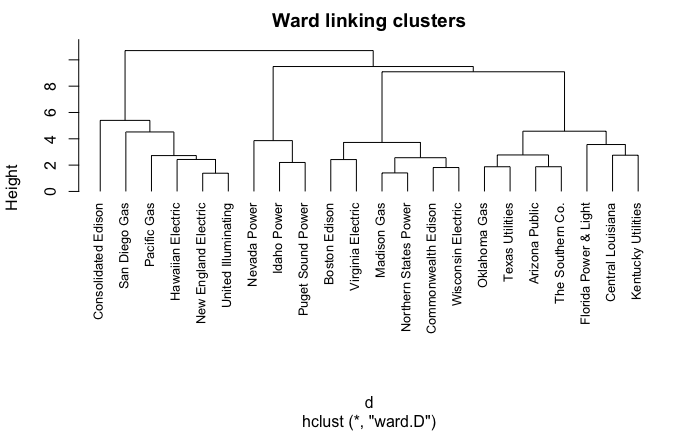

```r
fit.w <- hclust(d,method="ward.D")
plot(fit.w,hang=-1,cex=0.8,main="Ward linking clusters")
```

Now, let us examine the results for different cluster sizes

```r
clusters <- cutree(fit.w,k=4)
table(clusters)
```

```
clusters
1 2 3 4
7 6 6 3
```

```r
aggregate(putil,by=list(cluster=clusters),mean) #original form
```

[output not shown]

| cluster | Coverage | Return | Cost | Load | Peak | Sales | Nuclear | Fuel | Company |
| --- | --- | --- | --- | --- | --- | --- | --- | --- | --- |
| 1 | 1.207143 | 12.485714 | 127.5714 | 55.47143 | 1.714286 | 10163.14 | 3.214286 | 0.8744286 | NA |
| 2 | 1.075000 | 11.283333 | 181.3333 | 55.80000 | 3.500000 | 7087.50 | 36.116667 | 0.9021667 | NA |
| 3 | 1.100000 | 9.083333 | 174.8333 | 60.98333 | 3.216667 | 5988.00 | 4.133333 | 1.8381667 | NA |
| 4 | 1.003333 | 8.866667 | 223.3333 | 54.83333 | 6.333333 | 15504.67 | 0.000000 | 0.5656667 | NA |

```r
aggregate(putils,by=list(cluster=clusters),mean) #scaled form
```

| cluster | Coverage | Return | Cost | Load | Peak | Sales | Nuclear | Fuel |
| --- | --- | --- | --- | --- | --- | --- | --- | --- |
| 1 | 0.50431607 | 0.7795509 | -0.9858961 | -0.3375463 | -0.489576922 | 0.3518600 | -0.5232108 | -0.4105368 |
| 2 | -0.21186202 | 0.2437423 | 0.3192786 | -0.2638946 | 0.083088555 | -0.5145222 | 1.4362066 | -0.3606569 |
| 3 | -0.07636887 | -0.7366283 | 0.1614784 | 0.8979888 | -0.007774368 | -0.8242419 | -0.4684793 | 1.3224995 |
| 4 | -0.60027572 | -0.8331800 | 1.3389101 | -0.4805802 | 0.991717777 | 1.8565214 | -0.7146294 | -0.9657660 |

Now plot the results

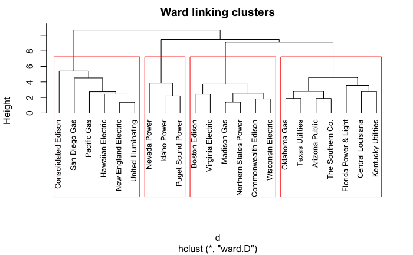

```r
plot(fit.w,hang=-1,cex=0.8,main="Ward linking clusters")
rect.hclust(fit.w,k=4)
```

```r
#install.packages("pvclust")
library(pvclust)
# pvclust clusters columns not rows, so transpose data
p1 <- as.data.frame(putil)
p1 <- p1[,-9]
p2 <- t(p1)
p2
```

```
         Arizona Public Boston Edison Central Louisiana Commonwealth Edison Consolidated Edison
Coverage          1.060         0.890             1.430                1.02               1.490
Return            9.200        10.300            15.400               11.20               8.800
Cost            151.000       202.000           113.000              168.00             192.000
Load             54.400        57.900            53.000               56.00              51.200
Peak              1.600         2.200             3.400                0.30               1.000
Sales          9077.000      5088.000          9212.000             6423.00            3300.000
Nuclear           0.000        25.300             0.000               34.30              15.600
Fuel              0.628         1.555             1.058                0.70               2.044
         Florida Power & Light Hawaiian Electric Idaho Power Kentucky Utilities Madison Gas Nevada Power
Coverage                 1.320             1.220       1.100              1.340       1.120        0.750
Return                  13.500            12.200       9.200             13.000      12.400        7.500
Cost                   111.000           175.000     245.000            168.000     197.000      173.000
Load                    60.000            67.600      57.000             60.400      53.000       51.500
Peak                    -2.200             2.200       3.300              7.200       2.700        6.500
Sales                11127.000          7642.000   13082.000           8406.000    6455.000    17441.000
Nuclear                 22.500             0.000       0.000              0.000      39.200        0.000
Fuel                     1.241             1.652       0.309              0.862       0.623        0.768
         New England Electric Northern States Power Oklahoma Gas Pacific Gas Puget Sound Power San Diego Gas
Coverage                1.130                 1.150        1.090        0.96              1.16          0.76
Return                 10.900                12.700       12.000        7.60              9.90          6.40
Cost                  178.000               199.000       96.000      164.00            252.00        136.00
Load                   62.000                53.700       49.800       62.20             56.00         61.90
Peak                    3.700                 6.400        1.400       -0.10              9.20          9.00
Sales                6154.000              7179.000     9673.000     6468.00          15991.00       5714.00
Nuclear                 0.000                50.200        0.000        0.90              0.00          8.30
Fuel                    1.897                 0.527        0.588        1.40              0.62          1.92
         The Southern Co. Texas Utilities Wisconsin Electric United Illuminating Virginia Electric
Coverage            1.050           1.160              1.200               1.040             1.070
Return             12.600          11.700             11.800               8.600             9.300
Cost              150.000         104.000            148.000             204.000           174.000
Load               56.700          54.000             59.900              61.000            54.300
Peak                2.700          -2.100              3.500               3.500             5.900
Sales           10140.000       13507.000           7287.000            6650.000         10093.000
Nuclear             0.000           0.000             41.100               0.000            26.600
Fuel                1.108           0.636              0.702               2.116             1.306
```

```r
fit <- pvclust(p2, method.hclust="ward.D2",
   method.dist="euclidean",nboot=220)
```

```
Bootstrap (r = 0.5)... Done.
Bootstrap (r = 0.5)... Done.
Bootstrap (r = 0.62)... Done.
Bootstrap (r = 0.75)... Done.
Bootstrap (r = 0.88)... Done.
Bootstrap (r = 1.0)... Done.
Bootstrap (r = 1.0)... Done.
Bootstrap (r = 1.12)... Done.
Bootstrap (r = 1.25)... Done.
Bootstrap (r = 1.38)... Done.
```

[output not shown]